# Introduction

I'm Marco Nashaat, a communication engineer in my senior year (at the time of this notebook) and I'm passionate about Data Analysis. This is the Google Data Analysis Capstone project which is the final step of a full specialisation which has been of great benefit to me and I'm excited that I've been this far in the program.

## Project objective

Help Cyclistic, a bike-share company in Chicago in their growth and help the company make more profit by designing a marketing strategy to convert casual riders into annual members.

### Goals

1. A clear statement of the business task
2. A description of all data sources used
3. Documentation of any cleaning or manipulation of data
4. A summary of the analysis
5. Supporting visualizations and key findings
6. Top three recommendations based on the analysis

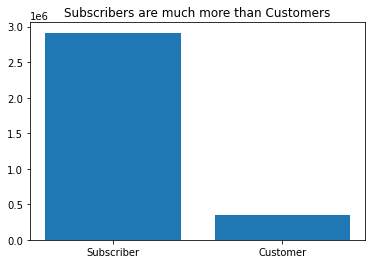

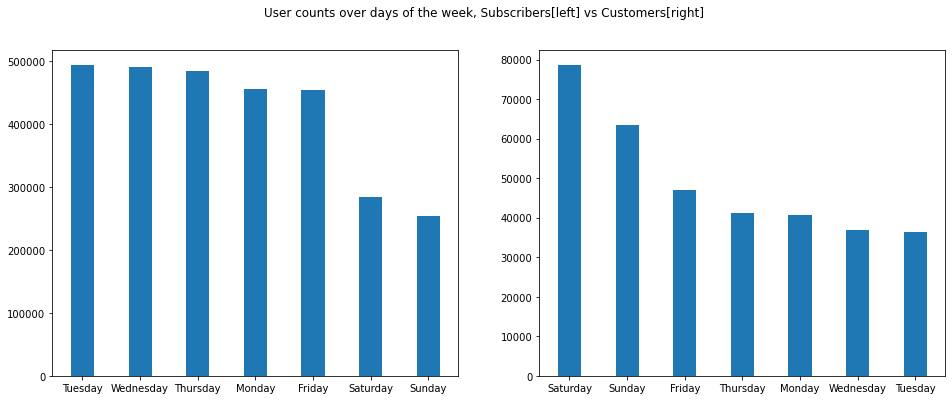

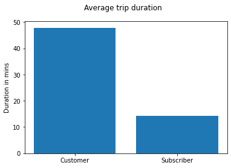

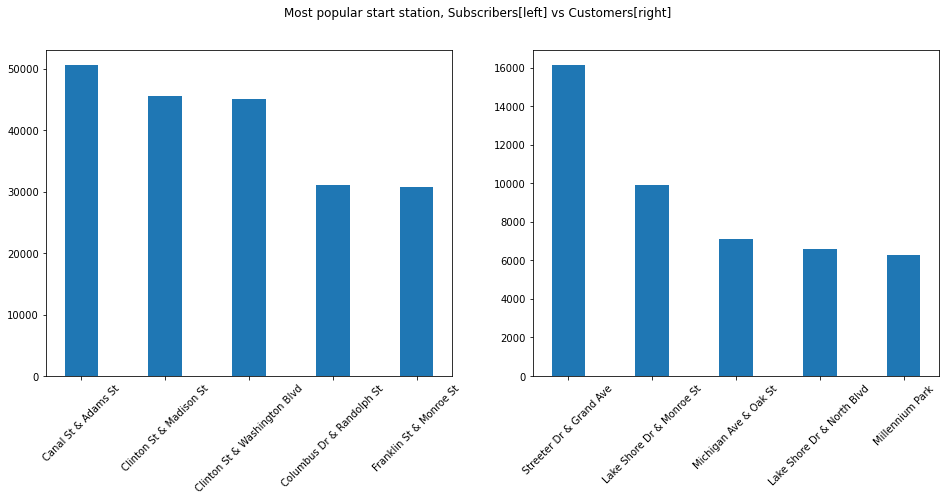

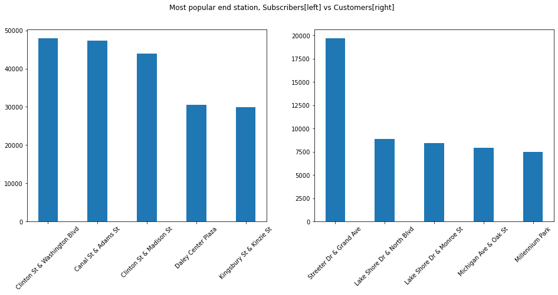

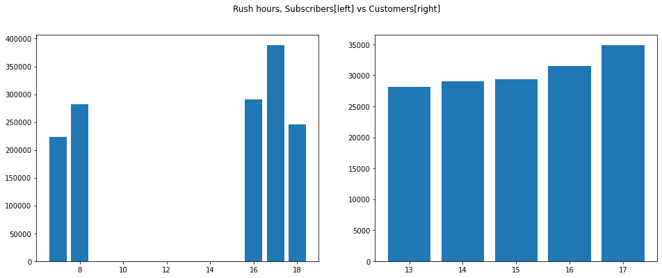

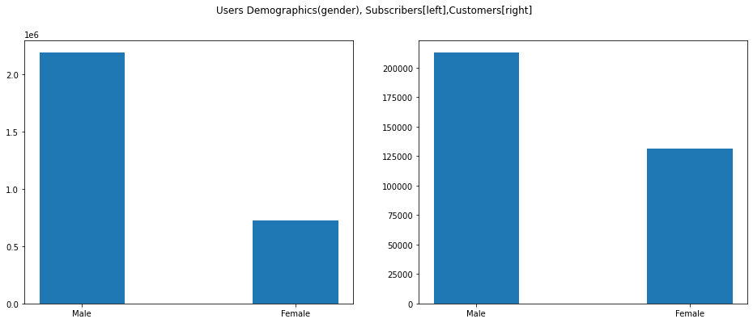

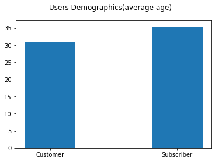

### Act phase

Top 3 recommendations based on my findings:

1. Advertise on 'Streeter Dr & Grand Ave', customers' most popular start and end station.
2. Raise prices on weekends(Saturday, and Sunday), the most popular days for customers to push them to buy a membership.
3. Raise prices during Rush hours (1pm:5pm).